# STS 112: Notebook 3

Mel Avina-Beltran

This week’s notebook focuses on thinking critically about race classification and making two-way tables. After working through this file, you will be able to:

- Recode nominal variables as factors.
- Make attractive two-way tables.
- Think historically and spatially.

These are all of the skills you will need to complete Lab 3.

## Read in and explore the data

Start by reading in the data for this week, saving as a dataframe called `ipums`. Instead of using the `readr` package like we did last week, we are going to use the `tidyverse` package, which includes `readr`, `dplyr`, `ggplot2` and many other useful packages. Make sure to install it before you run the following code. We will be loading more packages later on, so for each one, be sure to install the package (if you haven’t already done so) before running the `library()` function.

```r
install.packages("tidyverse")
```

```r
library(tidyverse)
```

```r
ipums <- read_csv("wk3.csv")
```

Let’s explore the dataset and read the codebook to figure out which samples we are working with and which variables are included. First use the `names()` function to see which variables are included.

```r
names(ipums)
```

```
[1] "YEAR"     "STATEFIP" "PERWT"    "RACE"     "RACED"
```

One quick way to get a sense of which samples we are working with is to make a histogram of `PERWT`, faceting by `YEAR`. Use `binwidth = 1`.

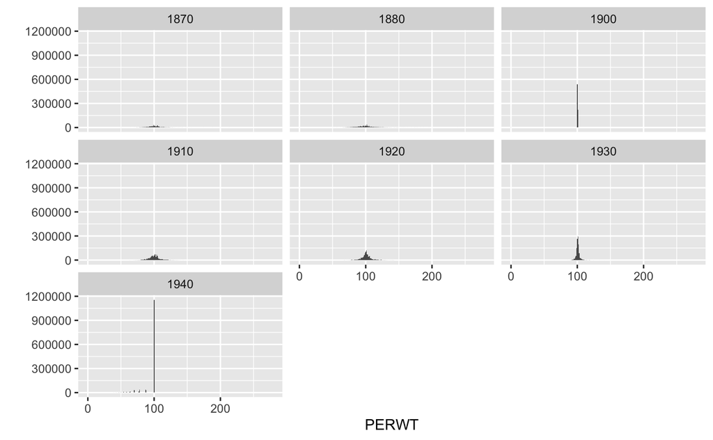

```r
qplot(PERWT, data=ipums,facets=~YEAR,binwidth=1)
```

## Recoding variables

Now let’s look at `RACE`. What happens when we plug it into `qplot()`?

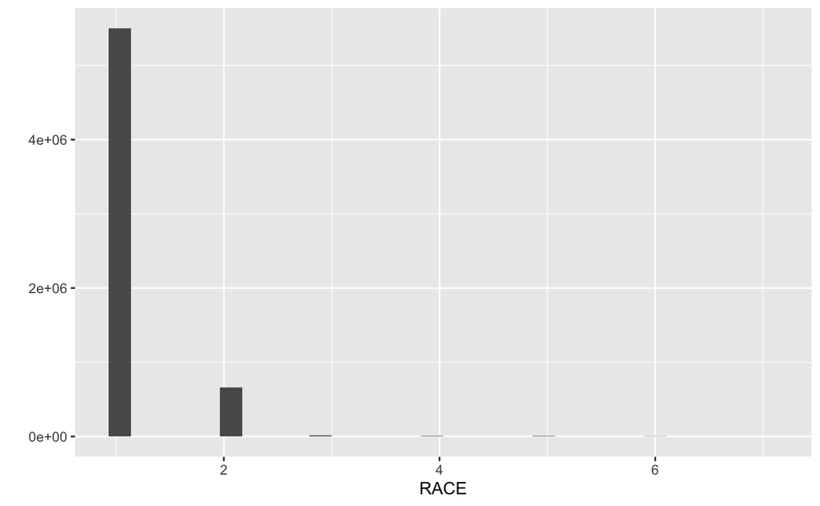

```r
qplot(RACE,data=ipums)
```

Since `RACE` is a nominal variable, we need to **recode** it to replace the numbers provided by IPUMS with the values they stand for. There are two ways we can do this. First, we can create a character variable that takes as values the text strings that correspond to the numbers in `RACE`. Use the codebook to match values to numbers. **It’s a good idea to start by checking which values of the variable in question are actually included in the data set.** So far we have been doing that with the `table()` function, which also tells us how many records have each value of the given variable. If we don’t need that information, we can use the `unique()` function, which returns a vector of unique values in the vector that is the argument to the function.

```r
unique(ipums$RACE)
```

```
[1] 2 1 4 3 5 6 7
```

If we want to see the elements of a vector in numeric (or alphabetical) order, we can sort them with the `sort()` function.

```r
sort(unique(ipums$RACE))
```

```
[1] 1 2 3 4 5 6 7
```

Now we will use this information, together with the codebook, to recode `RACE`, creating a new variable called `RACEC` and substituting for each numeric value of `RACE` its corresponding text value. For now, we will keep the values of the new character variable short so we can see them in the plots.

```r
ipums <- ipums %>% mutate(RACEC = ifelse(RACE == 1, "White",
                                  ifelse(RACE == 2, "Black",
                                  ifelse(RACE == 3, "Native",
                                  ifelse(RACE == 4, "Chinese",
                                  ifelse(RACE == 5, "Japanese",
                                  ifelse(RACE == 6, "OAIP","Other")))))))
```

What happens when we put our new variable into `qplot()`?

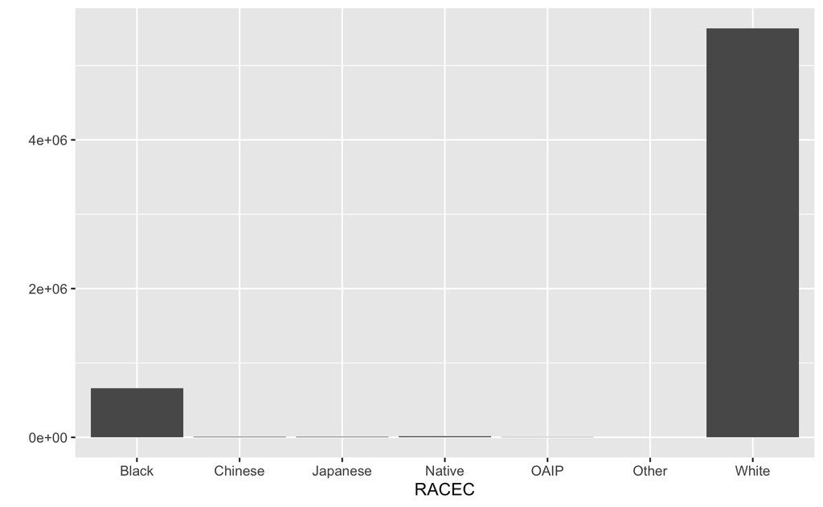

```r
qplot(RACEC,data=ipums)
```

Now `qplot()` gives us a bar chart because R knows we are dealing with a nominal variable.

The other way to recode `RACE` is to convert it to a **factor**. A factor is a data type that is stored as an integer, but each integer value is associated with a text label. Factors are more efficient for the computer to process than string variables, but R knows not to do math with them because the numeric values are symbolic. You can use factors for nominal and ordinal variables. The general form of the `factor()` function is `factor(<variable_to_recode>, labels = c("<value1>", "<value2>", ...))`. If you are using it to make a new column in a data frame, it would go inside a mutate function: `mutate(<name_of_new_column> = factor(<variable_to_recode>, labels = c("<value1>", "<value2>", ...)))`.

```r
ipums <- ipums %>% mutate(RACEF = factor(RACE,
                  labels = c("White", "Black", "Native",
                             "Chinese", "Japanese", "OAIP", "Other")))

#We also could have done it using <dataframe>$<column> notation instead of mutate():
ipums$RACEF <- factor(ipums$RACE,
                      labels = c("White", "Black", "Native",
                                 "Chinese", "Japanese", "OAIP", "Other"))

#Alternatively, we could have made a vector of labels first
race_labels <- c("White", "Black", "Native",
                 "Chinese", "Japanese", "OAIP", "Other")
#Then we can use this vector to convert RACE to a factor
ipums <- ipums %>% mutate(RACEF = factor(RACE, labels = race_labels))

#Or
ipums$RACEF <- factor(ipums$RACE, labels = race_labels)
```

Make a `qplot()` of `RACEF`.

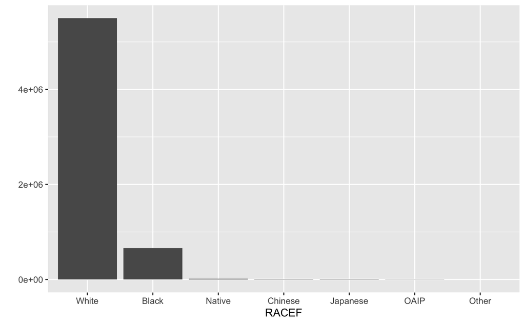

```r
qplot(RACEF,data=ipums)
```

## Two-way tables

The visualization we will be focusing on this week is the **table**. We have already used the `table()` function to make one-way tables. Do it now with `RACEF`.

```r
table(ipums$RACEF)
```

```
   White    Black   Native  Chinese Japanese     OAIP    Other
 5496581   661766    16012     6675     8557     3633        3
```

If we are interested in the way the racial composition of the U.S. population changed over time, this won’t help us much because it combines all of the years into a single table. If we want to see each year separately, we need a two-way table. We can do this by passing a second variable to the `table()` function. This is the **by** variable. If we want `RACEF` by `YEAR`, we do this:

```r
table(ipums$RACEF, ipums$YEAR)
```

```
              1870    1880    1900    1910    1920    1930    1940
  White     333630  434860  667498  817016  940062 1094963 1208552
  Black      48846   66253   87656  100279  104092  117526  137114
  Native       271     546    2587    2924    2513    3553    3618
  Chinese      611    1160    1193    1056     869    1004     782
  Japanese       0       0     781    1536    2242    2782    1216
  OAIP           0       0     366     342     856    1622     447
  Other          0       0       0       0       0       0       3
```

Note that the first variable specifies the rows and the second variable specifies the columns. This shows us how the number of people in each category changes from census to census in the *sample*, but how do we calculate the number in the entire *population*? We can’t just add the `weight` argument to the `table()` function, but the `questionr` package has a function called `wtd.table()` that does take a `weights` argument (note that it is “weights” and not “weight”).

```r
install.packages("questionr")
install.packages("htmltools")
library(questionr)
library(htmltools)
wtd.table(ipums$RACEF, ipums$YEAR, weights = ipums$PERWT)
```

```
                 1870         1880         1900         1910         1920         1930
White     33450927.15  43429564.17  66791705.00  81679876.78  94865922.08 110449666.05
Black      4868452.10   6554265.40   8783855.00  10014412.55  10499300.36  11891083.20
Native       27209.31     55568.72    259471.00    297099.15    255586.10    356219.25
Chinese      61382.82    113161.69    119453.00    103980.52     88272.39    101604.55
Japanese         0.00         0.00     78339.00    151650.52    225133.43    280214.65
OAIP             0.00         0.00     36717.00     33563.66     86116.90    164053.10
Other            0.00         0.00         0.00         0.00         0.00         0.00
                 1940
White    117094102.00
Black     12686890.00
Native      334359.00
Chinese      72703.00
Japanese    113222.00
OAIP         43717.00
Other          278.00
```

Now we have a new problem: decimals. People only come in integer values, so we want to round each value in our table to the nearest integer. We can do this with the `round()` function. The `round()` function takes two arguments: `round(<value_to_be_rounded>, <desired_number_of_decimals>)`. For example:

```r
round(5.9295702, 2)
```

```
[1] 5.93
```

```r
round(8.2950690, 0)
```

```
[1] 8
```

Since we want to round every value in our table, the whole `wtd.table()` function becomes the first argument to the `round()` function. Since we don’t want any decimals, the second argument is `0`.

```r
round(wtd.table(ipums$RACEF, ipums$YEAR, weights = ipums$PERWT), 0)
```

```
              1870      1880      1900      1910      1920      1930      1940
White     33450927  43429564  66791705  81679877  94865922 110449666 117094102
Black      4868452   6554265   8783855  10014413  10499300  11891083  12686890
Native       27209     55569    259471    297099    255586    356219    334359
Chinese      61383    113162    119453    103981     88272    101605     72703
Japanese         0         0     78339    151651    225133    280215    113222
OAIP             0         0     36717     33564     86117    164053     43717
Other            0         0         0         0         0         0       278
```

If we want to make our table easier to read, we can format it with the `format()` function. There are many ways to format a number, but in this case, we want to add commas as our thousands separator, which we do by specifying `big.mark=","` as the second argument to the `format()` function. The first argument is the number we are formatting, so the general form is `format(<number_to_be_formatted>, <format>)`.

```r
format(67828579, big.mark = ",")
```

```
[1] "67,828,579"
```

Notice that when we formatted the number, we turned it into a character string. Since we want to round and then format, our whole statement thus far becomes the first argument to the `format()` function:

```r
format(round(wtd.table(ipums$RACEF, ipums$YEAR, weights = ipums$PERWT), 0), big.mark = ",")
```

```
         1870          1880          1900          1910          1920          1930
White    " 33,450,927" " 43,429,564" " 66,791,705" " 81,679,877" " 94,865,922" "110,449,666"
Black    "  4,868,452" "  6,554,265" "  8,783,855" " 10,014,413" " 10,499,300" " 11,891,083"
Native   "     27,209" "     55,569" "    259,471" "    297,099" "    255,586" "    356,219"
Chinese  "     61,383" "    113,162" "    119,453" "    103,981" "     88,272" "    101,605"
Japanese "          0" "          0" "     78,339" "    151,651" "    225,133" "    280,215"
OAIP     "          0" "          0" "     36,717" "     33,564" "     86,117" "    164,053"
Other    "          0" "          0" "          0" "          0" "          0" "          0"
         1940
White    "117,094,102"
Black    " 12,686,890"
Native   "    334,359"
Chinese  "     72,703"
Japanese "    113,222"
OAIP     "     43,717"
Other    "        278"
```

It looks terrible, but we can fix that with the `kable()` function from the `knitr` package, which produces nice-looking tables. Our whole big long statement is the first argument to the `kable()` function. We don’t need any additional arguments, but if we want to add a caption, that is the second argument. The caption won’t print in the `.nb.html` output, but it will print in other output formats.

```r
library(knitr)

kable(format(round(wtd.table(ipums$RACEF, ipums$YEAR, weights = ipums$PERWT), 0), big.mark = ","),
      caption = "RACE by YEAR, 1870-1940")
```

RACE by YEAR, 1870-1940

|  | 1870 | 1880 | 1900 | 1910 | 1920 | 1930 | 1940 |
| --- | --- | --- | --- | --- | --- | --- | --- |
| White | 33,450,927 | 43,429,564 | 66,791,705 | 81,679,877 | 94,865,922 | 110,449,666 | 117,094,102 |
| Black | 4,868,452 | 6,554,265 | 8,783,855 | 10,014,413 | 10,499,300 | 11,891,083 | 12,686,890 |
| Native | 27,209 | 55,569 | 259,471 | 297,099 | 255,586 | 356,219 | 334,359 |
| Chinese | 61,383 | 113,162 | 119,453 | 103,981 | 88,272 | 101,605 | 72,703 |
| Japanese | 0 | 0 | 78,339 | 151,651 | 225,133 | 280,215 | 113,222 |
| OAIP | 0 | 0 | 36,717 | 33,564 | 86,117 | 164,053 | 43,717 |
| Other | 0 | 0 | 0 | 0 | 0 | 0 | 278 |

At this point, we have the `wtd.table()` function nested inside the `round()` function nested inside the `format()` function nested inside the `kable()` function. R doesn’t have any trouble parsing this, but it can get confusing for us since it requires us to think from the inside out rather than sequentially. Since we have the `tidyverse` package loaded, we can instead use pipes to direct our analysis from one function to another, even though these are not `dplyr` functions.

```r
wtd.table(ipums$RACEF, ipums$YEAR, weights = ipums$PERWT) %>%
  round(0) %>% format(big.mark = ",") %>% kable(caption = "RACE by YEAR, 1870 - 1940")
```

RACE by YEAR, 1870 - 1940

|  | 1870 | 1880 | 1900 | 1910 | 1920 | 1930 | 1940 |
| --- | --- | --- | --- | --- | --- | --- | --- |
| White | 33,450,927 | 43,429,564 | 66,791,705 | 81,679,877 | 94,865,922 | 110,449,666 | 117,094,102 |
| Black | 4,868,452 | 6,554,265 | 8,783,855 | 10,014,413 | 10,499,300 | 11,891,083 | 12,686,890 |
| Native | 27,209 | 55,569 | 259,471 | 297,099 | 255,586 | 356,219 | 334,359 |
| Chinese | 61,383 | 113,162 | 119,453 | 103,981 | 88,272 | 101,605 | 72,703 |
| Japanese | 0 | 0 | 78,339 | 151,651 | 225,133 | 280,215 | 113,222 |
| OAIP | 0 | 0 | 36,717 | 33,564 | 86,117 | 164,053 | 43,717 |
| Other | 0 | 0 | 0 | 0 | 0 | 0 | 278 |

## Questioning unexpected results

Take a look at the table we created. Notice that, from 1930 to 1940, the number of people in the “Chinese”, “Japanese”, and “Other Asian and Pacific Islander” categories falls dramatically. Why is that? Take a look at the [documentation for the 1940 sample](https://usa.ipums.org/usa/sampdesc.shtml#us1940a).

Alaska and Hawaii are included in the 1900-1930 samples, but not in the 1940 sample. Is it possible that the omission of AK/HI from the 1940 sample is responsible for the apparent decline of people in the “Chinese”, “Japanese”, and “Other Asian/Pacific Islander” categories?

One way to figure this out would be to look at our data separately for AK/HI and the other states. We can use the `STATEFIP` variable to designate each row in our data as either in AK/HI or in another state. Look at the codebook to find the values of `STATEFIP` that denote Alaska and Hawaii. Test your result.

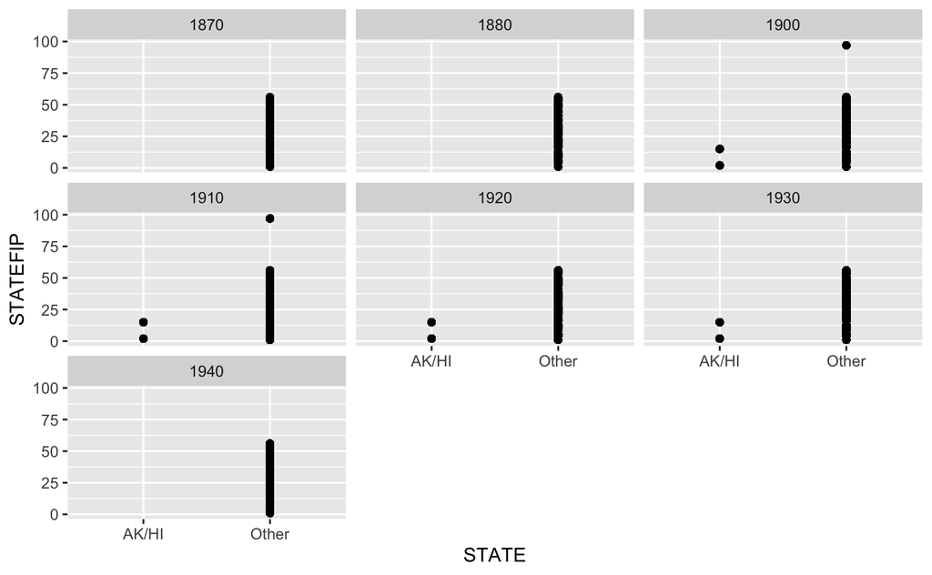

```r
ipums <- ipums %>% mutate(STATE = ifelse(STATEFIP %in% c(2,15), "AK/HI", "Other"))
qplot(STATE, STATEFIP, data = ipums, facets = ~YEAR)
```

Now let’s make a `qplot()` of `RACEF`, faceting by `YEAR` (rows) and `STATE` (columns). Weight by `PERWT`.

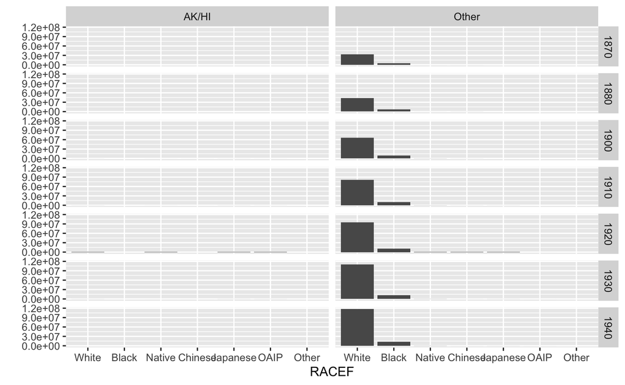

```r
qplot(RACEF,data=ipums,facets=YEAR~STATE,weight=PERWT)
```

It is hard to see what is going on here because the number of people classified as “White” or “Black” is so much larger than the number of people in the other categories. Since we are only concerned with the people in the categories that reference Asian and Pacific Islander nationalities, let’s filter the `ipums` data frame to only include people with values of `RACE` greater than 3.

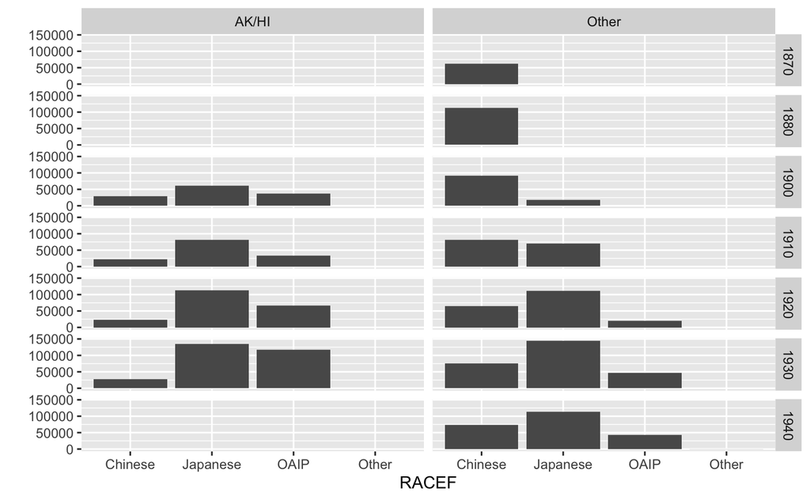

```r
qplot(RACEF,data=filter(ipums,RACE>3),facets=YEAR~STATE,weight=PERWT)
```

## Dealing with data inconsistencies

The IPUMS samples for 1940-1950 do not include Alaska and Hawaii, but the samples for 1900-1930 and 1960-2010 do. We have seen that this can create unexpected results, potentially leading to incorrect interpretations. To keep our analyses consistent, any time our analysis includes 1940 and/or 1950, together with one or more samples from 1900-1930, we must remove records for Alaska and Hawaii from the 1900-1930 samples, and explain in our methodology why we did this. It is fine to leave Alaska and Hawaii in the 1960-2010 samples, but we must alert our audience to the fact that these states are missing from earlier samples. Both Alaska and Hawaii attained statehood in 1959.

Make the table of `RACEF` by `YEAR` again, this time eliminating records for Alaska and Hawaii.

```r
ipums<-ipums %>% filter(!STATEFIP %in% c(2,15))

wtd.table(ipums$RACEF, ipums$YEAR, weights = ipums$PERWT) %>%
  round(0) %>% format(big.mark = ",") %>% kable(caption = "RACE by YEAR, 1870 - 1940")
```

RACE by YEAR, 1870 - 1940

|  | 1870 | 1880 | 1900 | 1910 | 1920 | 1930 | 1940 |
| --- | --- | --- | --- | --- | --- | --- | --- |
| White | 33,450,927 | 43,429,564 | 66,725,757 | 81,594,549 | 94,790,646 | 110,335,271 | 117,094,102 |
| Black | 4,868,452 | 6,554,265 | 8,783,054 | 10,013,387 | 10,498,906 | 11,889,562 | 12,686,890 |
| Native | 27,209 | 55,569 | 230,306 | 266,648 | 223,515 | 331,050 | 334,359 |
| Chinese | 61,383 | 113,162 | 90,844 | 81,097 | 65,527 | 74,808 | 72,703 |
| Japanese | 0 | 0 | 17,065 | 70,108 | 111,835 | 145,006 | 113,222 |
| OAIP | 0 | 0 | 0 | 0 | 19,664 | 46,116 | 43,717 |
| Other | 0 | 0 | 0 | 0 | 0 | 0 | 278 |

Data visualizations never speak for themselves. When I ask you what your data visualization *is* I am asking you to give your reader enough information so that they could re-create your visualization and interprt if for themselves. When I ask you what it *shows* I am asking you to interpret your own visualization drawing on what you have learned

Explain what this visualiation *is*:

> This table shows the number of people classified in each category of the IPUMS variable `RACE` in each census year from 1870 to 1940, with the exception of 1890, for which manuscript records were destroyed. It is constructed from IPUMS 1% samples for each year, weighting by `PERWT`. Alaska and Hawaii have been excluded because data are not consistently available for those states during this period. The `RACE` variable groups together as “White” people who were classified by census enumerators as “White”, “Portuguese”, “Mexican”, or “Puerto Rican”. It groups together as “Black” people who were classified by census enumerators as “Negro” or “Mulatto”. It groups together as “Other Asian or Pacific Islander” (OAIP in map above) people who were classified by census enumerators as “Filipino”, “Hindu”, or “Korean”. Complete documentation for `RACE` is available on the [IPUMS website](https://usa.ipums.org/usa-action/variables/RACE#description_section).

What does this table *show*? How you would explain and interpret this table?:

> *Note: This is just a small part of the text you would need to fully interpret the table; use it as an example for how you would discuss the parts I have not discussed here.* This table shows growth in all categories of `RACE` between 1870 and 1940, but the growth is not always linear, and extreme caution must be taken in interpreting the data. The “White” category, which is by far the largest, conceals intense debate during this period of heavy immigration over which groups of immigrants would count as white (Hochschild and Powell 75-77). The stakes were not trivial, as naturalization was limited to people who were either white or black, and nonwhites faced various degrees of segregation and disenfranchisement in many parts of the country. The “Black” category ostensibly includes all individuals with African ancestry, even though the Census Bureau attempted to identify mixed-race individuals between 1850 and 1920 (Hochschild and Powell 66-71). The dramatic growth in the “Native” category reflects changes in the way Native Americans were counted by the census, rather than growth in the Native American population. Native Americans were classified inconsistently over time, with those who lived among white Americans often classified as white (Hochschild and Powell 77-80). *More text here about the other rows of the table.* While this table does give some indication of the changing racial composition of the U.S. population, it does so more in the addition of categories over time than in the actual numbers. By grouping together some of the people who were originally classified separately in the census, the IPUMS `RACE` variable facilitates analysis over time but conceals change over time in the ways Americans understood race and classified people into racial categories.

> Works Cited:  
> Hochschild, Jennifer L. and Brenna Marea Powell, “Racial Reorganizationa nd the United States Census 1850-1930: Mulattoes, Half-Breeds, Mixed Parentage, Hindoos, and the Mexican Race,” *Studies in American Political Development* 22, 2008, pp. 59-96.